# Home Work Assignment - 03

Critical Thinking Group 5

# Overview

To attain our objective, we will be following the below best practice steps and guidelines:  
1 -Data Exploration  
2 -Data Preparation  
3 -Build Models  
4 -Select Models

# Overview

To attain our objective, we will be following the below best practice steps and guidelines:  
1 -Data Exploration  
2 -Data Preparation  
3 -Build Models  
4 -Select Models

```
## 'data.frame':    466 obs. of  14 variables:
##  $ zn     : num  0 0 0 30 0 0 0 0 0 80 ...
##  $ indus  : num  19.58 19.58 18.1 4.93 2.46 ...
##  $ chas   : int  0 1 0 0 0 0 0 0 0 0 ...
##  $ nox    : num  0.605 0.871 0.74 0.428 0.488 0.52 0.693 0.693 0.515 0.392 ...
##  $ rm     : num  7.93 5.4 6.49 6.39 7.16 ...
##  $ age    : num  96.2 100 100 7.8 92.2 71.3 100 100 38.1 19.1 ...
##  $ dis    : num  2.05 1.32 1.98 7.04 2.7 ...
##  $ rad    : int  5 5 24 6 3 5 24 24 5 1 ...
##  $ tax    : int  403 403 666 300 193 384 666 666 224 315 ...
##  $ ptratio: num  14.7 14.7 20.2 16.6 17.8 20.9 20.2 20.2 20.2 16.4 ...
##  $ black  : num  369 397 387 375 394 ...
##  $ lstat  : num  3.7 26.82 18.85 5.19 4.82 ...
##  $ medv   : num  50 13.4 15.4 23.7 37.9 26.5 5 7 22.2 20.9 ...
##  $ target : int  1 1 1 0 0 0 1 1 0 0 ...
```

```
##        zn             indus             chas              nox
##  Min.   :  0.00   Min.   : 0.460   Min.   :0.00000   Min.   :0.3890
##  1st Qu.:  0.00   1st Qu.: 5.145   1st Qu.:0.00000   1st Qu.:0.4480
##  Median :  0.00   Median : 9.690   Median :0.00000   Median :0.5380
##  Mean   : 11.58   Mean   :11.105   Mean   :0.07082   Mean   :0.5543
##  3rd Qu.: 16.25   3rd Qu.:18.100   3rd Qu.:0.00000   3rd Qu.:0.6240
##  Max.   :100.00   Max.   :27.740   Max.   :1.00000   Max.   :0.8710
##        rm             age              dis              rad
##  Min.   :3.863   Min.   :  2.90   Min.   : 1.130   Min.   : 1.00
##  1st Qu.:5.887   1st Qu.: 43.88   1st Qu.: 2.101   1st Qu.: 4.00
##  Median :6.210   Median : 77.15   Median : 3.191   Median : 5.00
##  Mean   :6.291   Mean   : 68.37   Mean   : 3.796   Mean   : 9.53
##  3rd Qu.:6.630   3rd Qu.: 94.10   3rd Qu.: 5.215   3rd Qu.:24.00
##  Max.   :8.780   Max.   :100.00   Max.   :12.127   Max.   :24.00
##       tax           ptratio         black            lstat
##  Min.   :187.0   Min.   :12.6   Min.   :  0.32   Min.   : 1.730
##  1st Qu.:281.0   1st Qu.:16.9   1st Qu.:375.61   1st Qu.: 7.043
##  Median :334.5   Median :18.9   Median :391.34   Median :11.350
##  Mean   :409.5   Mean   :18.4   Mean   :357.12   Mean   :12.631
##  3rd Qu.:666.0   3rd Qu.:20.2   3rd Qu.:396.24   3rd Qu.:16.930
##  Max.   :711.0   Max.   :22.0   Max.   :396.90   Max.   :37.970
##       medv           target
##  Min.   : 5.00   Min.   :0.0000
##  1st Qu.:17.02   1st Qu.:0.0000
##  Median :21.20   Median :0.0000
##  Mean   :22.59   Mean   :0.4914
##  3rd Qu.:25.00   3rd Qu.:1.0000
##  Max.   :50.00   Max.   :1.0000
```

```
## 'data.frame':    40 obs. of  13 variables:
##  $ zn     : int  0 0 0 0 0 25 25 0 0 0 ...
##  $ indus  : num  7.07 8.14 8.14 8.14 5.96 5.13 5.13 4.49 4.49 2.89 ...
##  $ chas   : int  0 0 0 0 0 0 0 0 0 0 ...
##  $ nox    : num  0.469 0.538 0.538 0.538 0.499 0.453 0.453 0.449 0.449 0.445 ...
##  $ rm     : num  7.18 6.1 6.5 5.95 5.85 ...
##  $ age    : num  61.1 84.5 94.4 82 41.5 66.2 93.4 56.1 56.8 69.6 ...
##  $ dis    : num  4.97 4.46 4.45 3.99 3.93 ...
##  $ rad    : int  2 4 4 4 5 8 8 3 3 2 ...
##  $ tax    : int  242 307 307 307 279 284 284 247 247 276 ...
##  $ ptratio: num  17.8 21 21 21 19.2 19.7 19.7 18.5 18.5 18 ...
##  $ black  : num  393 380 388 233 397 ...
##  $ lstat  : num  4.03 10.26 12.8 27.71 8.77 ...
##  $ medv   : num  34.7 18.2 18.4 13.2 21 18.7 16 26.6 22.2 21.4 ...
```

# 1 Data Exploration Analysis

In section we will explore and gain some insights into the dataset by pursuing the below high level steps and inquiries:  
-Variable identification  
-Variable Relationships  
-Data summary analysis  
-Outliers and Missing Values Identification

## 1.1 Variable identification

First let’s display and examine the data dictionary or the data columns as shown in table 1 and proportion of success and failure cases in target variable.

```
##        zn             indus             chas              nox
##  Min.   :  0.00   Min.   : 0.460   Min.   :0.00000   Min.   :0.3890
##  1st Qu.:  0.00   1st Qu.: 5.145   1st Qu.:0.00000   1st Qu.:0.4480
##  Median :  0.00   Median : 9.690   Median :0.00000   Median :0.5380
##  Mean   : 11.58   Mean   :11.105   Mean   :0.07082   Mean   :0.5543
##  3rd Qu.: 16.25   3rd Qu.:18.100   3rd Qu.:0.00000   3rd Qu.:0.6240
##  Max.   :100.00   Max.   :27.740   Max.   :1.00000   Max.   :0.8710
##        rm             age              dis              rad
##  Min.   :3.863   Min.   :  2.90   Min.   : 1.130   Min.   : 1.00
##  1st Qu.:5.887   1st Qu.: 43.88   1st Qu.: 2.101   1st Qu.: 4.00
##  Median :6.210   Median : 77.15   Median : 3.191   Median : 5.00
##  Mean   :6.291   Mean   : 68.37   Mean   : 3.796   Mean   : 9.53
##  3rd Qu.:6.630   3rd Qu.: 94.10   3rd Qu.: 5.215   3rd Qu.:24.00
##  Max.   :8.780   Max.   :100.00   Max.   :12.127   Max.   :24.00
##       tax           ptratio         black            lstat
##  Min.   :187.0   Min.   :12.6   Min.   :  0.32   Min.   : 1.730
##  1st Qu.:281.0   1st Qu.:16.9   1st Qu.:375.61   1st Qu.: 7.043
##  Median :334.5   Median :18.9   Median :391.34   Median :11.350
##  Mean   :409.5   Mean   :18.4   Mean   :357.12   Mean   :12.631
##  3rd Qu.:666.0   3rd Qu.:20.2   3rd Qu.:396.24   3rd Qu.:16.930
##  Max.   :711.0   Max.   :22.0   Max.   :396.90   Max.   :37.970
##       medv           target
##  Min.   : 5.00   Min.   :0.0000
##  1st Qu.:17.02   1st Qu.:0.0000
##  Median :21.20   Median :0.0000
##  Mean   :22.59   Mean   :0.4914
##  3rd Qu.:25.00   3rd Qu.:1.0000
##  Max.   :50.00   Max.   :1.0000
```

```
##
##         0         1
## 0.5085837 0.4914163
```

In section we will explore and gain some insights into the dataset by pursuing the below high level steps and inquiries:  
-Variable identification  
-Variable Relationships  
-Data summary analysis  
-Outliers and Missing Values Identification

## 1.1 Variable identification

First let’s display and examine the data dictionary or the data columns as shown in table 1.

|  | zn | indus | chas | nox | rm | age | dis | rad | tax | ptratio | black | lstat | medv | target |
| --- | --- | --- | --- | --- | --- | --- | --- | --- | --- | --- | --- | --- | --- | --- |
|  | Min. : 0.00 | Min. : 0.460 | Min. :0.00000 | Min. :0.3890 | Min. :3.863 | Min. : 2.90 | Min. : 1.130 | Min. : 1.00 | Min. :187.0 | Min. :12.6 | Min. : 0.32 | Min. : 1.730 | Min. : 5.00 | Min. :0.0000 |
|  | 1st Qu.: 0.00 | 1st Qu.: 5.145 | 1st Qu.:0.00000 | 1st Qu.:0.4480 | 1st Qu.:5.887 | 1st Qu.: 43.88 | 1st Qu.: 2.101 | 1st Qu.: 4.00 | 1st Qu.:281.0 | 1st Qu.:16.9 | 1st Qu.:375.61 | 1st Qu.: 7.043 | 1st Qu.:17.02 | 1st Qu.:0.0000 |
|  | Median : 0.00 | Median : 9.690 | Median :0.00000 | Median :0.5380 | Median :6.210 | Median : 77.15 | Median : 3.191 | Median : 5.00 | Median :334.5 | Median :18.9 | Median :391.34 | Median :11.350 | Median :21.20 | Median :0.0000 |
|  | Mean : 11.58 | Mean :11.105 | Mean :0.07082 | Mean :0.5543 | Mean :6.291 | Mean : 68.37 | Mean : 3.796 | Mean : 9.53 | Mean :409.5 | Mean :18.4 | Mean :357.12 | Mean :12.631 | Mean :22.59 | Mean :0.4914 |
|  | 3rd Qu.: 16.25 | 3rd Qu.:18.100 | 3rd Qu.:0.00000 | 3rd Qu.:0.6240 | 3rd Qu.:6.630 | 3rd Qu.: 94.10 | 3rd Qu.: 5.215 | 3rd Qu.:24.00 | 3rd Qu.:666.0 | 3rd Qu.:20.2 | 3rd Qu.:396.24 | 3rd Qu.:16.930 | 3rd Qu.:25.00 | 3rd Qu.:1.0000 |
|  | Max. :100.00 | Max. :27.740 | Max. :1.00000 | Max. :0.8710 | Max. :8.780 | Max. :100.00 | Max. :12.127 | Max. :24.00 | Max. :711.0 | Max. :22.0 | Max. :396.90 | Max. :37.970 | Max. :50.00 | Max. :1.0000 |

## 1.2 Data Summary Analysis

In this section, we will create summary data to better understand the initial relationship variables have with our dependent variable using correlation, central tendency, and dispersion As shown in table 2.

```
##         vars   n   mean     sd median trimmed    mad    min    max  range
## zn         1 466  11.58  23.36   0.00    5.35   0.00   0.00 100.00 100.00
## indus      2 466  11.11   6.85   9.69   10.91   9.34   0.46  27.74  27.28
## chas       3 466   0.07   0.26   0.00    0.00   0.00   0.00   1.00   1.00
## nox        4 466   0.55   0.12   0.54    0.54   0.13   0.39   0.87   0.48
## rm         5 466   6.29   0.70   6.21    6.26   0.52   3.86   8.78   4.92
## age        6 466  68.37  28.32  77.15   70.96  30.02   2.90 100.00  97.10
## dis        7 466   3.80   2.11   3.19    3.54   1.91   1.13  12.13  11.00
## rad        8 466   9.53   8.69   5.00    8.70   1.48   1.00  24.00  23.00
## tax        9 466 409.50 167.90 334.50  401.51 104.52 187.00 711.00 524.00
## ptratio   10 466  18.40   2.20  18.90   18.60   1.93  12.60  22.00   9.40
## black     11 466 357.12  91.32 391.34  383.51   8.24   0.32 396.90 396.58
## lstat     12 466  12.63   7.10  11.35   11.88   7.07   1.73  37.97  36.24
## medv      13 466  22.59   9.24  21.20   21.63   6.00   5.00  50.00  45.00
## target    14 466   0.49   0.50   0.00    0.49   0.00   0.00   1.00   1.00
##          skew kurtosis   se
## zn       2.18     3.81 1.08
## indus    0.29    -1.24 0.32
## chas     3.34     9.15 0.01
## nox      0.75    -0.04 0.01
## rm       0.48     1.54 0.03
## age     -0.58    -1.01 1.31
## dis      1.00     0.47 0.10
## rad      1.01    -0.86 0.40
## tax      0.66    -1.15 7.78
## ptratio -0.75    -0.40 0.10
## black   -2.92     7.34 4.23
## lstat    0.91     0.50 0.33
## medv     1.08     1.37 0.43
## target   0.03    -2.00 0.02
```

```
##      zn   indus    chas     nox      rm     age     dis     rad     tax
##       0       0       0       0       0       0       0       0       0
## ptratio   black   lstat    medv  target
##       0       0       0       0       0
```

Correlation between target and predictor variable

|  | Correlation |
| --- | --- |
| zn | -0.4316818 |
| indus | 0.6048507 |
| chas | 0.0800419 |
| nox | 0.7261062 |
| rm | -0.1525533 |
| age | 0.6301062 |
| dis | -0.6186731 |
| rad | 0.6281049 |
| tax | 0.6111133 |
| ptratio | 0.2508489 |
| black | -0.3529568 |
| lstat | 0.4691270 |
| medv | -0.2705507 |
| target | 1.0000000 |

## 1.3 Outliers and Missing Values Identification

In this section we look at boxplots to determine the outliers in variables and decide on whether to act on the outliers.

Lets do some univariate analysis. We will look at the Histogram and Boxplot for each variable to detect outliers if any and treat it accordingly.

Analysis of variable zn:proportion of residential land zoned for large lots

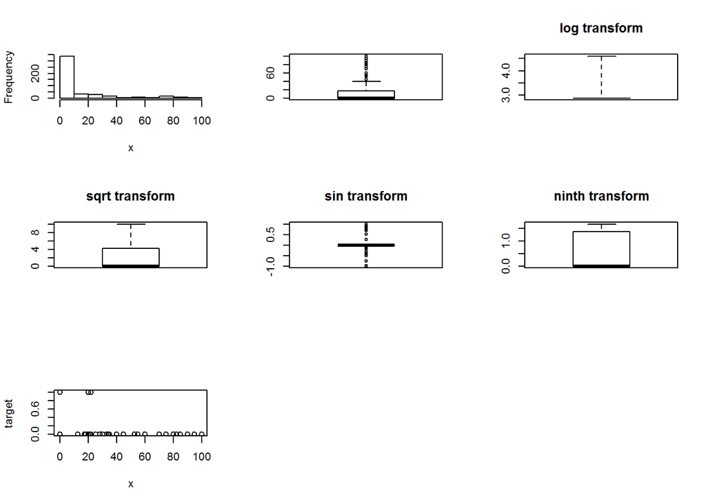

Lets do some univariate analysis. We will look at the Histogram and Boxplot for each variable to detect outliers if any and treat it accordingly.

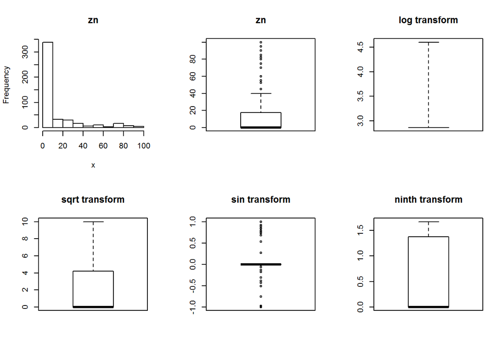

zn Transformation

For zn, we can see that there are large number of values with 0. ninth transformation seem better for this variable..(1)

**Please note that we have created similar figures to figure 1 above for each remaining variable. However, we hid the remaining figures for ease of streamlining the report as they have similar shapes. However, we have drawn the below observations from each remaining figure.

For indus, we can see that there is a spike toward right side of he distribution. Looking at the sqrt transformation it appears that distribution is close to normal and having two peaks after transformation.

For nox, there is a long right tail.

For rm, there are some outliers as we can see from box plot. This variable will need some transformation to handle the outliers.

For rad variable distribution is not uniform as seen from the chart and will need transformation.

For tax variable is not uniformly distributed but there is no outlier for this variable.

For pratio has right aligned peak but no outliers are there in data set.

# 2. Data Preparation

Now that we have completed the preliminary analysis, we will be cleaning and consolidating data into one dataset for use in analysis and modeling. We will be puring the belwo steps as guidlines:  
- Outliers treatment  
- Missing values treatment  
- Data transformation

## 2.1 Outliers treatment

For outliers, we will create 2 sets of variables.

The first set uses the capping method. In this method, we will replace all outliers that lie outside the 1.5 times of IQR limits. We will cap it by replacing those observations less than the lower limit with the value of 5th %ile and those that lie above the upper limit with the value of 95th %ile.

Accordingly we create the following new variables while retaining the original variables.

city_crime_train$tax\ city_crime_train$medv  
city_crime_train$lstat

Lets see how the new variables look in boxplots.

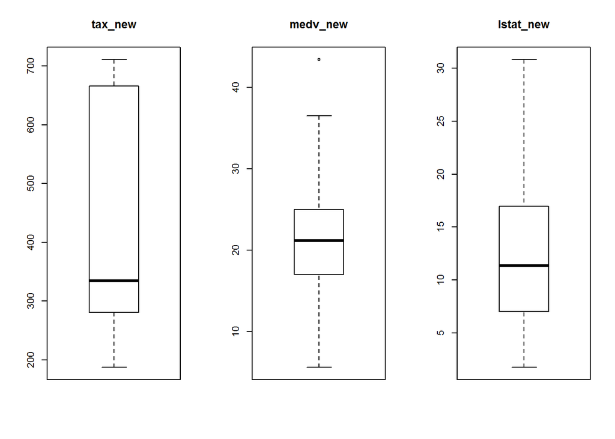

In the second set, we will use the sin transformation and create the following variables:

city_crime_train$rm_new\ city_crime_train$dis_new

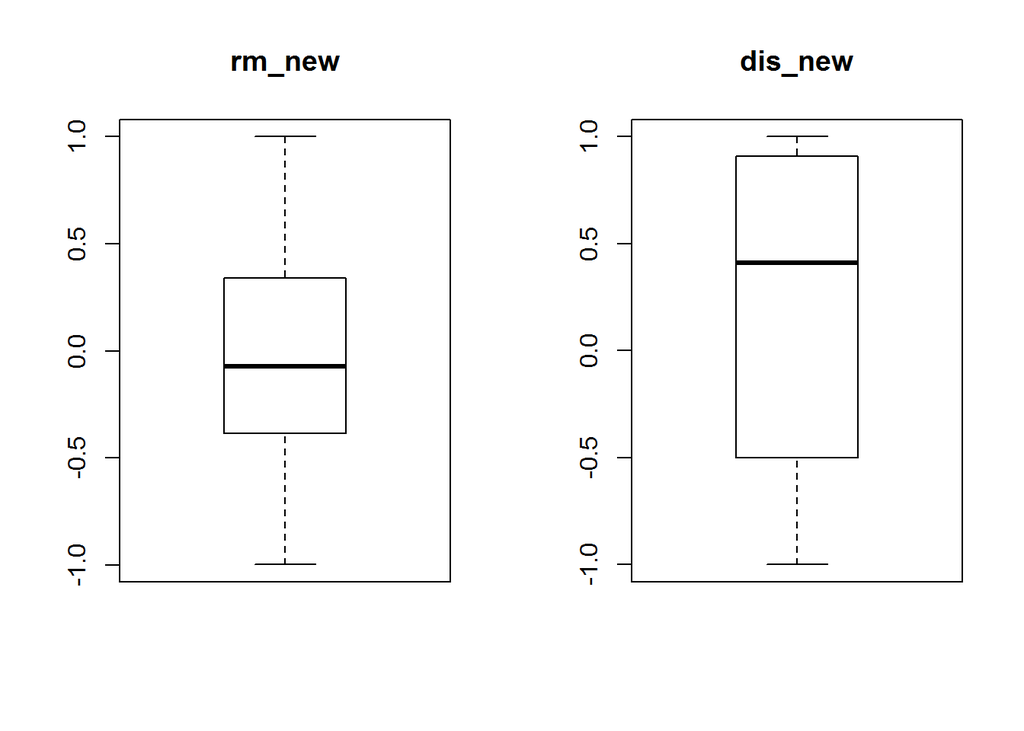

## 2.3 Tranformation for Variables

Following variables will need some transformation:

1. zn: proportion of residential land zoned for large lots (over 25000 square feet) (predictor variable)
2. chas: a dummy var. for whether the suburb borders the Charles River (1) or not (0) (predictor variable)
3. target: whether the crime rate is above the median crime rate (1) or not (0) (response variable)

# 3 Build Models

## 3.1 Model One

```
##
## Call:
## glm(formula = target ~ . - zn_new - rm_new - lstat_new - tax_new -
##     medv_new, family = "binomial", data = city_crime_train)
##
## Deviance Residuals:
##     Min       1Q   Median       3Q      Max
## -1.8469  -0.1389  -0.0017   0.0007   3.3050
##
## Coefficients:
##               Estimate Std. Error z value Pr(>|z|)
## (Intercept) -39.967503   7.480155  -5.343 9.14e-08 ***
## zn           -0.014489   0.028929  -0.501  0.61649
## indus         0.003888   0.055889   0.070  0.94454
## chas1         0.464046   0.743387   0.624  0.53248
## nox          53.269267   8.209555   6.489 8.66e-11 ***
## rm           -0.862730   0.851113  -1.014  0.31075
## age           0.041618   0.015426   2.698  0.00698 **
## dis           0.476938   0.276948   1.722  0.08505 .
## rad           0.800898   0.200223   4.000 6.33e-05 ***
## tax          -0.005040   0.003082  -1.635  0.10201
## ptratio       0.442846   0.142815   3.101  0.00193 **
## black        -0.011963   0.005945  -2.012  0.04421 *
## lstat         0.036461   0.057025   0.639  0.52257
## medv          0.230818   0.078475   2.941  0.00327 **
## dis_new      -1.892538   0.477332  -3.965 7.34e-05 ***
## ---
## Signif. codes:  0 '***' 0.001 '**' 0.01 '*' 0.05 '.' 0.1 ' ' 1
##
## (Dispersion parameter for binomial family taken to be 1)
##
##     Null deviance: 645.88  on 465  degrees of freedom
## Residual deviance: 165.64  on 451  degrees of freedom
## AIC: 195.64
##
## Number of Fisher Scoring iterations: 9
```

```
##
## target FALSE TRUE
##      0   234    3
##      1    35  194
```

### 3.1 Model One with backward step function

```r
stepmodel1<- step(model1, direction="backward")
```

```
## Start:  AIC=195.64
## target ~ (zn + indus + chas + nox + rm + age + dis + rad + tax +
##     ptratio + black + lstat + medv + tax_new + medv_new + lstat_new +
##     rm_new + dis_new + zn_new) - zn_new - rm_new - lstat_new -
##     tax_new - medv_new
##
##           Df Deviance    AIC
## - indus    1   165.64 193.64
## - zn       1   165.91 193.91
## - chas     1   166.02 194.02
## - lstat    1   166.04 194.04
## - rm       1   166.67 194.67
## <none>         165.63 195.63
## - tax      1   168.25 196.25
## - dis      1   168.29 196.29
## - black    1   170.84 198.84
## - age      1   173.83 201.83
## - medv     1   175.65 203.65
## - ptratio  1   176.06 204.06
## - dis_new  1   186.15 214.15
## - rad      1   197.68 225.68
## - nox      1   246.22 274.22
##
## Step:  AIC=193.64
## target ~ zn + chas + nox + rm + age + dis + rad + tax + ptratio +
##     black + lstat + medv + dis_new
##
##           Df Deviance    AIC
## - zn       1   165.93 191.93
## - lstat    1   166.05 192.05
## - chas     1   166.08 192.08
## - rm       1   166.68 192.68
## <none>         165.64 193.64
## - dis      1   168.29 194.29
## - tax      1   168.88 194.88
## - black    1   170.88 196.88
## - age      1   173.85 199.85
## - medv     1   175.68 201.68
## - ptratio  1   176.11 202.11
## - dis_new  1   188.52 214.52
```

[output cut: 41 more lines]

```
## target ~ nox + rm + age + dis + rad + tax + ptratio + black +
##     medv + dis_new
##
##           Df Deviance    AIC
## <none>         166.88 188.88
## - dis      1   169.24 189.24
## - rm       1   169.51 189.51
## - tax      1   170.28 190.28
## - black    1   171.96 191.96
## - medv     1   177.75 197.75
## - ptratio  1   179.47 199.47
## - age      1   180.74 200.74
## - dis_new  1   195.77 215.77
## - rad      1   209.89 229.89
## - nox      1   258.55 278.55
```

```r
pre_train1_step<-predict(stepmodel1,type="response")

table(target,pre_train1_step >0.75)
```

```
##
## target FALSE TRUE
##      0   234    3
##      1    34  195
```

## 3.2 Model two

In this model, we will be using the some transformed variables.

First we will produce the summary model as per below:

```
##
## Call:
## glm(formula = target ~ . - zn - rm - dis - tax - lstat - medv,
##     family = "binomial", data = city_crime_train)
##
## Deviance Residuals:
##     Min       1Q   Median       3Q      Max
## -1.7978  -0.1372  -0.0012   0.0006   3.7479
##
## Coefficients:
##               Estimate Std. Error z value Pr(>|z|)
## (Intercept) -41.631145   7.066597  -5.891 3.83e-09 ***
## indus         0.010371   0.055697   0.186 0.852285
## chas1         0.386972   0.716324   0.540 0.589045
## nox          49.978105   7.574874   6.598 4.17e-11 ***
## age           0.039466   0.014272   2.765 0.005689 **
## rad           0.823571   0.203804   4.041 5.32e-05 ***
## ptratio       0.432948   0.150308   2.880 0.003972 **
## black        -0.011718   0.005890  -1.990 0.046641 *
## tax_new      -0.005283   0.003017  -1.751 0.079911 .
## medv_new      0.224594   0.067847   3.310 0.000932 ***
## lstat_new     0.021292   0.063375   0.336 0.736891
## rm_new       -1.395547   0.963844  -1.448 0.147646
## dis_new      -2.328906   0.475160  -4.901 9.52e-07 ***
## zn_new1       0.296890   0.802123   0.370 0.711285
## ---
## Signif. codes:  0 '***' 0.001 '**' 0.01 '*' 0.05 '.' 0.1 ' ' 1
##
## (Dispersion parameter for binomial family taken to be 1)
##
##     Null deviance: 645.88  on 465  degrees of freedom
## Residual deviance: 167.31  on 452  degrees of freedom
## AIC: 195.31
##
## Number of Fisher Scoring iterations: 9
```

```
##
## target FALSE TRUE
##      0   235    2
##      1    34  195
```

### 3.1 Model two with backward step function

```r
stepmodel2<- step(model2, direction="backward")
```

```
## Start:  AIC=195.31
## target ~ (zn + indus + chas + nox + rm + age + dis + rad + tax +
##     ptratio + black + lstat + medv + tax_new + medv_new + lstat_new +
##     rm_new + dis_new + zn_new) - zn - rm - dis - tax - lstat -
##     medv
##
##             Df Deviance    AIC
## - indus      1   167.35 193.35
## - lstat_new  1   167.43 193.43
## - zn_new     1   167.45 193.45
## - chas       1   167.60 193.60
## <none>           167.31 195.31
## - rm_new     1   169.44 195.44
## - tax_new    1   170.33 196.33
## - black      1   172.33 198.33
## - age        1   175.88 201.88
## - ptratio    1   176.18 202.18
## - medv_new   1   180.15 206.15
## - dis_new    1   199.36 225.36
## - rad        1   200.70 226.70
## - nox        1   257.91 283.91
##
## Step:  AIC=193.35
## target ~ chas + nox + age + rad + ptratio + black + tax_new +
##     medv_new + lstat_new + rm_new + dis_new + zn_new
##
##             Df Deviance    AIC
## - zn_new     1   167.47 191.47
## - lstat_new  1   167.47 191.47
## - chas       1   167.72 191.72
## <none>           167.35 193.35
## - rm_new     1   169.45 193.45
## - tax_new    1   170.82 194.82
## - black      1   172.40 196.40
## - age        1   175.88 199.88
## - ptratio    1   176.20 200.20
## - medv_new   1   180.20 204.20
## - dis_new    1   201.51 225.51
## - rad        1   207.02 231.02
## - nox        1   269.29 293.29
```

[output cut: 36 more lines]

```
## Step:  AIC=188.11
## target ~ nox + age + rad + ptratio + black + tax_new + medv_new +
##     rm_new + dis_new
##
##            Df Deviance    AIC
## <none>          168.12 188.12
## - tax_new   1   171.58 189.58
## - rm_new    1   171.61 189.61
## - black     1   172.85 190.85
## - ptratio   1   178.87 196.87
## - age       1   180.79 198.79
## - medv_new  1   181.00 199.00
## - dis_new   1   203.04 221.04
## - rad       1   210.44 228.44
## - nox       1   273.82 291.82
```

```r
pre_train2_step<-predict(stepmodel2,type="response")

table(target,pre_train2_step >0.75)
```

```
##
## target FALSE TRUE
##      0   235    2
##      1    34  195
```

```
## zn
##    0 12.5 17.5   18   20   21   22   25   28   30   33   34   35   40   45
##  339   10    1    1   21    4    9    8    3    6    3    3    3    7    6
## 52.5   55   60   70   75   80 82.5   85   90   95  100
##    3    3    4    3    3   13    2    2    4    4    1
```

For ZN, we can see that there are large number of values with 0.

**Please note that we have created similar figures to figure 1 above for each remaining variable. However, we hid the remaining figures for ease of streamlining the report as they have similar shapes. However, we have drawn the below observations from each remaining figure.

```
## indus
##  0.46  0.74  1.21  1.22  1.25  1.32  1.38  1.47  1.52  1.69  1.89  1.91
##     1     1     1     1     2     1     1     2     4     2     1     2
##  2.02  2.03  2.18  2.24  2.25  2.31  2.46  2.68  2.89  2.93  2.95  3.24
##     1     2     6     3     1     1     8     2     4     2     2     3
##  3.33  3.37  3.41  3.44  3.64  3.75  3.78  3.97     4  4.05  4.15  4.39
##     4     2     4     6     2     1     2    12     1     7     1     2
##  4.49  4.86  4.93  4.95  5.13  5.19  5.32  5.64  5.86  5.96  6.06  6.07
##     2     4     6     3     4     7     3     4     9     3     2     3
##  6.09   6.2  6.41  6.91  6.96  7.07  7.38  7.87  8.14  8.56  9.69   9.9
##     3    16     5     9     5     1     6     7    19    11     7    11
## 10.01 10.59 10.81 11.93 12.83 13.89 13.92 15.04  18.1 19.58 21.89 25.65
##     9    10     4     4     6     4     5     3   121    28    14     5
## 27.74
##     5
```

```
##    Min. 1st Qu.  Median    Mean 3rd Qu.    Max.
##   0.460   5.145   9.690  11.110  18.100  27.740
```

For indus, we can see that there is a spike toward right side of he distribution. Looking at the sqrt transformation it appears that distribution is close to normal and having two peaks after transformation.

```
##    Min. 1st Qu.  Median    Mean 3rd Qu.    Max.
##  0.3890  0.4480  0.5380  0.5543  0.6240  0.8710
```

For nox, there is a long right tail.

```
##    Min. 1st Qu.  Median    Mean 3rd Qu.    Max.
##   3.863   5.887   6.210   6.291   6.630   8.780
```

For rm, there are some outliers as we can see from box plot.

For this variable dis, there are some outliers which needs transformation to handle those outliers. Sin transformation looks best suited for this scenario.

```
## rad
##   1   2   3   4   5   6   7   8  24
##  17  20  36 103 109  25  15  20 121
```

For rad variable distribution is not uniform as seen from the chart and will need transformation.

```
## tax
## 187 188 193 198 216 222 223 224 226 233 242 243 244 245 247 252 254 255
##   1   5   8   1   5   6   5   9   1   9   1   4   1   3   2   2   5   1
## 256 264 265 270 273 276 277 279 281 284 287 289 293 296 300 304 305 307
##   1  12   2   7   4   8  10   3   4   5   6   5   3   8   7  13   4  35
## 311 313 315 329 330 334 335 337 345 348 351 352 358 370 384 391 398 402
##   7   1   2   6   9   2   2   2   3   2   1   2   3   2  11   7  12   2
## 403 411 422 430 432 437 469 666 711
##  28   2   1   3   9  14   1 121   5
```

For tax variable is not uniformly distributed but there is no outlier for this variable.

For pratio has right aligned peak but no outliers are there in data set.

The variable medv has close to normal distribution and lot of outliers towers uppper end. Looks like sin transformation is requried in this scenario.